# Hyperopt-Sklearn: Really Simple Hyperparameter Optimization

by Matthew Emery [@lstmemery](https://github.com/lstmemery/hyperopt-sklearn/tree/master/hpsklearn)

## What Is Hyperparameter Optimization?

- Every choice you make about a machine learning model you use is a hyperparameter
- This includes the choice of model itself as well as preprocessing steps
- Every dataset will have slightly different optimal hyperparameters

## What Makes Hyperparameter Optimization Tough?

- There are an infinite number of hyperparameters.
- Many of those hyperparameters can take an infinite number of values.
- Hyperparameters can interact with each other in unpredictable ways
- Evaluating hyperparameters means training a new model
- That's computationally expensive

## Classic Hyperparameter Optimization (Found in Sklearn)

- Grid search divides the hyperparameter space into even-spaced grids
- Random search just guesses totally randomly
- Random search is almost always a better idea then grid search

[figure not shown]

## Can we do better than random?

This is known as Sequential Model-Based Optimization

1. Gaussian Processes (GPyOpt)
2. **Tree-based Parzen Windows (Hyperopt)**

## What is Hyperopt?

- Bayesian: The algorithm will stop picking values correlated with bad validation scores (As opposed to random search)
- Tree-based: The algorithm can model discrete, conditional, categorical and continuous variables

## What is Hyperopt-Sklearn?

- A wrapper for Hyperopt compatible with the scikit-learn API
- Also includes reasonable prior distributions for many scikit-learn models (plug and play)
- Supports XGBoost
- Checkout my fork of it is here: https://github.com/lstmemery/hyperopt-sklearn
- My main contribution: Fixing cross-validation, adding repeated cross-validation

[figure not shown]

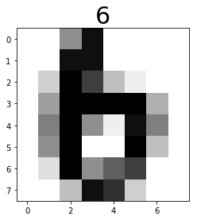

```python
X, y = load_digits(return_X_y = True) # MNIST Dataset

(train_X, test_X, train_y, test_y) = train_test_split(X, y,
                                     test_size = 0.2,
                                     random_state = 0) # Split the Data
random_image = randint(0, len(train_X))
plt.title(train_y[random_image], fontsize=30)
plt.imshow(train_X[random_image].reshape(8, 8), cmap=plt.cm.gray_r)
```

```
0.944
```

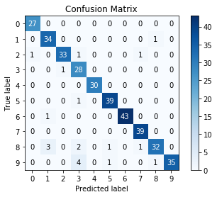

```python
model = RandomForestClassifier(random_state = 0) # Basic Random Forest
model.fit(train_X, train_y)
print(accuracy_score(test_y, model.predict(test_X)).round(3))

skplt.metrics.plot_confusion_matrix(test_y, model.predict(test_X)) # Lookup Scikit-plot!
```

```python
from hpsklearn import HyperoptEstimator, any_classifier

hyperopt_model = HyperoptEstimator(classifier=any_classifier("mnist"),
                                   max_evals=100,
                                   seed=0)
hyperopt_model.fit(train_X,
              train_y,
              n_folds=5,
              cv_shuffle=True,
              random_state=0)

from sklearn.externals import joblib

joblib.dump(hyperopt_model, "hyperopt_model.pkl")
```

```
['hyperopt_model.pkl']
```

```
0.989
{'learner': KNeighborsClassifier(algorithm='auto', leaf_size=30, metric='euclidean',
           metric_params=None, n_jobs=1, n_neighbors=3, p=2,
           weights='distance'), 'preprocs': (Normalizer(copy=True, norm='l2'),), 'ex_preprocs': ()}
```

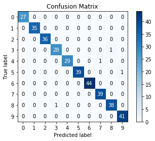

```python
hyperopt_model = joblib.load("hyperopt_model.pkl")
hyperopt_predictions = hyperopt_model.predict(test_X)

print(accuracy_score(test_y, hyperopt_predictions).round(3))
print(hyperopt_model.best_model())
skplt.metrics.plot_confusion_matrix(test_y, hyperopt_predictions)
```

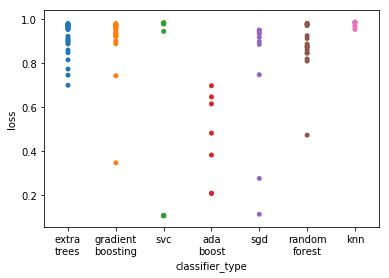

```python
sns.stripplot(x="classifier_type", y="loss", data= pd.DataFrame(classifier_performance))
```

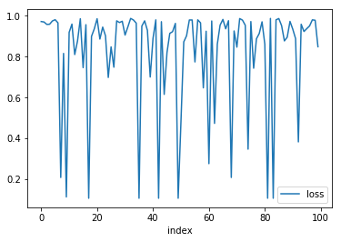

```python
pd.DataFrame(classifier_performance).plot.line(x="index", y="loss")
```

## Other Features

- Parallel Optimization through MongoDB
- Warm Starting (don't start from square one every time)

## What about Neural Networks?

- The Hyperopt library can be used to optimize any function
- Some kind soul built a keras-compatibility layer called [Hyperas](https://github.com/maxpumperla/hyperas)

## Words to the Wise

- Hyperparameter optimization is computationally costly
- Your ideal hyperparameters will shift depending on feature engineering
- Create a few basic models first and see if validation accuracy improves
- **Don't do hyperparameter tuning until you are reasonably certain you won't be making big changes**

## Optimization Bias

- In the example above I used 5-fold cross validation
- The more iterations of hyperparameter tuning you run, the more likely that you find a model that fits the validation data by chance (overfitting)
- If overfitting is an issue, increase your fold size or even perform cross-validation multiple times per iteration and average the results

## Other Hyperparameter Libraries

- Hyperband (subsampling, early-stopping random search)
- TPOT (Evolutionary pipeline building)
- Auto-sklearn (Ensemble building and meta-learning)